# Semanário Leg.go

## Pressão e Temperatura

#### Evolução da Pressão e Temperatura ao longo das semanas

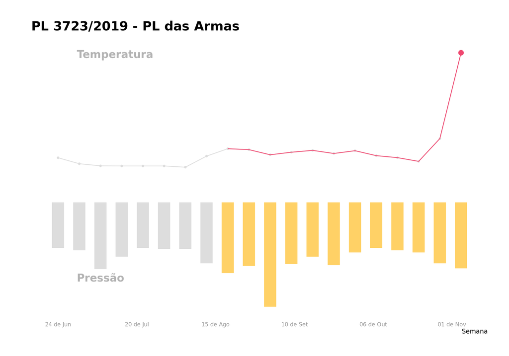

Foi observado um crescimento de 449% na temperatura e um crescimento de 6% na pressão. Os eventos que influenciaram a Temperatura estão na tabela abaixo.

| Data-Hora | Local | Evento | Detalhamento |
| --- | --- | --- | --- |
| 2019-11-05 00:00:00 | PLEN | Parecer pela Aprovação | Parecer às Emendas de Plenário proferido pelo Relator, Dep. Alexandre Leite (DEM-SP), pela Comissão Especial destinada a proferir parecer ao Projeto de Lei nº 3723, de 2019,que conclui pela constituci… |
| 2019-11-05 14:00:00 | PLEN | Designação de Relator | Designado Relator, Dep. Alexandre Leite (DEM-SP), para proferir Parecer às Emendas de Plenário pela Comissão Especial. |
| 2019-11-05 19:58:00 | PLEN | Parecer pela Aprovação | Aprovada a Subemenda Substitutiva Global Reformulada de Plenário ao Projeto de Lei nº 3.723, de 2019, adotada pelo Relator da Comissão Especial, ressalvados os destaques. Sim 283; não 140; abstenção 2… |
| 2019-11-05 19:58:00 | PLEN | Parecer pela Aprovação com Substitutivo | Em consequência, fica prejudicada a apreciação da Proposição inicial, do Substitutivo e das Emendas apresentadas, ressalvados os destaques. |
| 2019-11-05 19:58:00 | PLEN | Parecer pela Aprovação | Aprovada a Emenda nº 113. |
| 2019-11-05 19:58:00 | PLEN | Parecer pela Aprovação com Substitutivo | Retirado o DTQ 5: PT: Destaque do art. 2-A da Lei nº 10826/2003, na redação do artigo 1º do substitutivo apresentado ao PL 3723/2019 (161,I). |
| 2019-11-05 19:58:00 | PLEN | Parecer pela Aprovação com Substitutivo | Retirado o DTQ 6: PT: Destaque do §5º do art. 5º da Lei 10826/03, na redação do artigo 1º do substitutivo apresentado ao PL 3723/2019 (161,I). |
| 2019-11-05 19:58:00 | PLEN | Parecer pela Aprovação com Substitutivo | Retirado o DTQ 10: Ricardo Izar: Destaque para votação em separado da seção III do Substitutivo oferecido ao PL 3723/19 (art. 161, V). |
| 2019-11-05 19:58:00 | PLEN | Parecer pela Aprovação com Substitutivo | Retirado o DTQ 12: PT: Destaque do ART. 5º-A da Lei 10826/03, na redação do artigo 1º do substitutivo apresentado ao PL 3723/2019 (161,I). |
| 2019-11-05 19:58:00 | PLEN | Parecer pela Aprovação com Substitutivo | Retirado o DTQ 17: PCdoB: Destaque do §4º do art. 6º da Lei 10826/70 constante do art. 1º do Substitutivo (art. 161). |
| 2019-11-05 19:58:00 | PLEN | Parecer pela Aprovação com Substitutivo | Retirado o DTQ 38: DEM: Destaque de preferência para votação do art. 6º da Lei 10826/03 com a redação dada pelo Substitutivo apresentado ao PL 3723/19, com vistas a substituir o art. 6º da Lei 10826/0… |
| 2019-11-05 19:58:00 | PLEN | Parecer pela Aprovação com Substitutivo | Retirado o DTQ 39: DEM: Destaque de preferência para votação do art. 10 da Lei 10826/03 com a redação dada pelo art. 1º do Substitutivo apresentado ao PL 3723/19, com vistas a substituir o mesmo artig… |
| 2019-11-05 19:58:00 | PLEN | Parecer pela Aprovação com Substitutivo | Retirado o DTQ 40: PSL: Destaque para votação em separado do art. 5º da lei 10.826/2003, com a redação dada pelo art. 1º do Substitutivo apresentado ao PL 3723/19, para incluir, onde couber, no texto … |
| 2019-11-05 19:58:00 | PLEN | Parecer pela Aprovação com Substitutivo | Retirado o DTQ 52: PSL: Destaque do art. 6º do Substitutivo apresentado ao PL 3723/2019 para que substitua o art. 6º da Subemenda Substitutiva. (161, IV). |
| 2019-11-05 19:58:00 | PLEN | Parecer pela Aprovação com Substitutivo | Retirado o DTQ 55: DEM : Destaque de preferência para votação do art. 6º da Lei 10826/03 com a redação dada pelo Substitutivo apresentado ao PL 3723/19, com vistas a substituir o art. 6º da Lei 10826/… |
| 2019-11-05 19:58:00 | PLEN | Parecer pela Aprovação com Substitutivo | Retirado o DTQ 56: DEM: Destaque do art. 10 da Lei 10826/2003, com redação dada pelo art. 1º do Substitutivo com vistas a substituir a redação dada pela Subemenda Substitutiva (161, IV). |
| 2019-11-05 19:58:00 | PLEN | Parecer pela Aprovação | Aprovada a Redação Final assinada pelo Relator, Dep. Alexandre Leite (DEM-SP). |
| 2019-11-07 00:00:00 | MESA | Virada de Casa | Remessa ao Senado Federal por meio do Of. nº 1.302/19/SGM-P. |

## Atores

#### Documentos autorados pelos parlamentares última semana

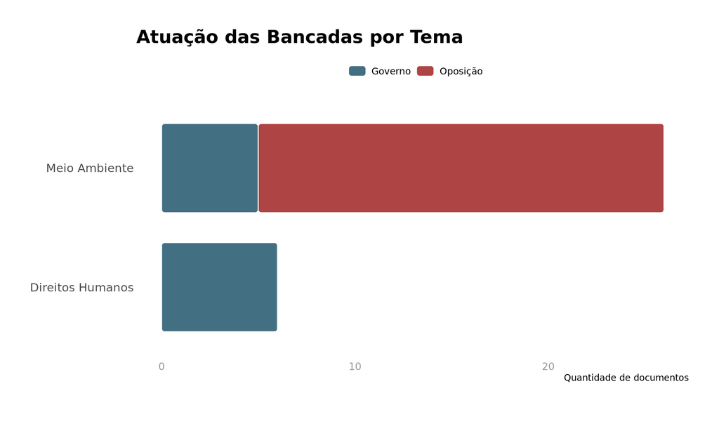

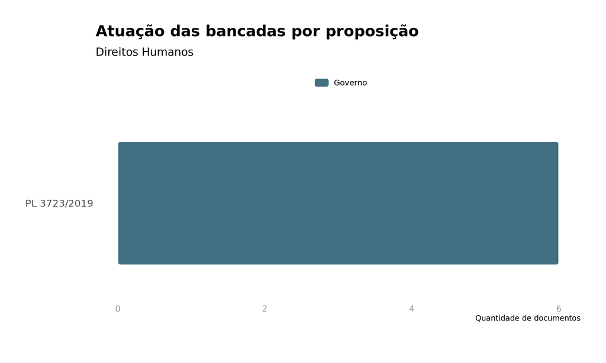

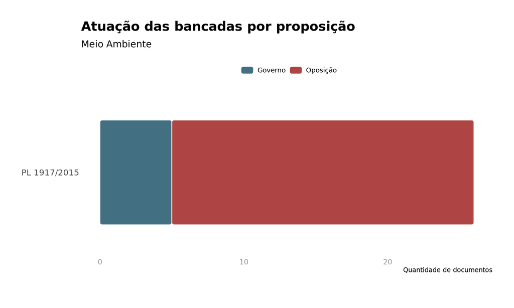

A PL 1917/2015 teve maior número de atuações, com apresentação de 26 documentos, sendo 5 apresentados pelo governo e 21 pela oposição. Abaixo, temos mais detalhes sobre os atores e os respectivos documentos apresentados.

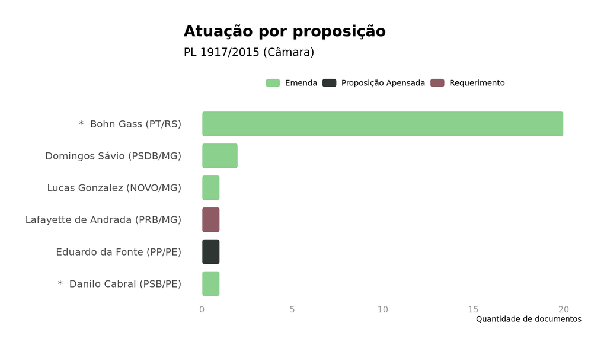

Para mais informações sobre a proposição, como o progresso, a rede de influência e uma análise sobre as emendas, [clique aqui](https://leggo.org.br/#/proposicao/%2058). Abaixo, temos mais detalhes sobre os atores e os respectivos documentos apresentados.

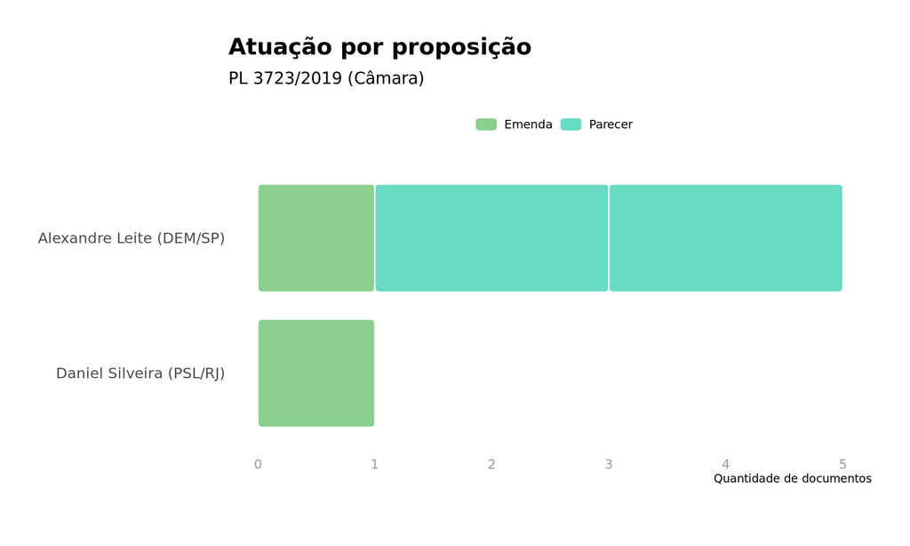

Para mais informações sobre a proposição, como o progresso, a rede de influência e uma análise sobre as emendas, [clique aqui](https://leggo.org.br/#/proposicao/%2065).